# DAPR2 10 – RQ1 step by step

```r
# # load libraries
library(tidyverse)  # for all things!
# library(psych)      # good for descriptive stats
# library(kableExtra) # useful for creating nice tables
# library(sjPlot)     # regression tables & plots
# library(emmeans)    # for contrasts
# library(car)        # for assumptions (crPlots, residualPlots, VIF) and bootstrapping

data1 <- read_csv("https://uoepsy.github.io/data/DapR2_S1B2_PracticalPart1.csv")
```

RQ1: Does conscientiousness, frequency of access to online materials, and year of study in University predict course attendance?

# (1) Before model fitting

## Identify the relevant variables

```r
head(data1)
```

| pid | Attendance | Conscientiousness | Time | OnlineAccess | Year |
| --- | --- | --- | --- | --- | --- |
| 1 | 9 | High | 3PM | Often | Y3 |
| 2 | 10 | High | 2PM | Often | Y3 |
| 3 | 0 | Low | 10AM | Rarely | Y2 |
| 4 | 8 | Low | 4PM | Often | Y4 |
| 5 | 6 | High | 4PM | Sometimes | Y1 |
| 6 | 6 | High | 9AM | Sometimes | Y1 |

RQ1: Does conscientiousness, frequency of access to online materials, and year of study in University predict course attendance?

- `Conscientiousness`
- `OnlineAccess`
- `Year`
- `Attendance`

## Data tidying (e.g., missingness? factor levels?)

### missingness

```r
is.na(data1) |> table()
```

```
FALSE
 2382
```

No NAs.

### factor levels

`Conscientiousness`:

```r
unique(data1$Conscientiousness)
```

```
[1] "High"     "Low"      "Moderate"
```

We’ll make “Moderate” the reference level, so one coef will compare that to “High” and the other will compare it to “Low”.

`OnlineAccess`

```r
unique(data1$OnlineAccess)
```

```
[1] "Often"     "Rarely"    "Sometimes"
```

We’ll make “Sometimes” the reference level, so one coef will compare that to “Often” and the other will compare it to “Rarely”.

`Year`

```r
unique(data1$Year)
```

```
[1] "Y3"  "Y2"  "Y4"  "Y1"  "MSc" "PhD"
```

We’ll make this chronological, so Y1 will be the reference level.

```r
data1 <- data1 |>
  mutate(
    Conscientiousness = factor(Conscientiousness, levels = c('Moderate', 'High', 'Low')),
    OnlineAccess = factor(OnlineAccess, levels = c('Sometimes', 'Often', 'Rarely')),
    Year = factor(Year, levels = c('Y1', 'Y2', 'Y3', 'Y4', 'MSc', 'PhD'))
  )
```

## Get summary statistics for the relevant variables

`Conscientiousness` – categorical

```r
data1$Conscientiousness |> table()
```

```
Moderate     High      Low
     146      124      127
```

Mode = ‘Moderate’ conscientiousness

`OnlineAccess` – categorical

```r
data1$OnlineAccess |> table()
```

```
Sometimes     Often    Rarely
      170       126       101
```

Mode = ‘Sometimes’ online access

`Year` – categorical

```r
data1$Year |> table()
```

```
 Y1  Y2  Y3  Y4 MSc PhD
 89 100  66  71  48  23
```

Mode = Y2

`Attendance` – continuous

```r
data1$Attendance |> psych::describe()
```

|  | vars | n | mean | sd | median | trimmed | mad | min | max | range | skew | kurtosis | se |
| --- | --- | --- | --- | --- | --- | --- | --- | --- | --- | --- | --- | --- | --- |
| X1 | 1 | 397 | 28.28 | 13.99 | 29 | 28.31 | 16.31 | 0 | 60 | 60 | -0.03 | -1 | 0.7 |

## Plot each relevant variable individually

`Conscientiousness` – categorical

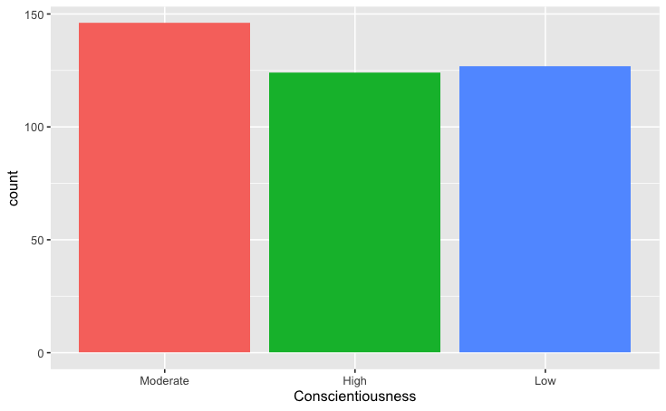

```r
data1 |>
  ggplot(aes(x = Conscientiousness, fill = Conscientiousness)) +
  geom_bar() +
  theme(legend.position = 'none')
```

`OnlineAccess` – categorical

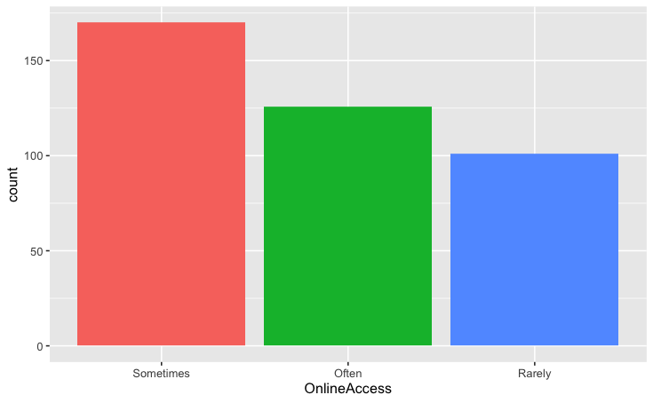

```r
data1 |>
  ggplot(aes(x = OnlineAccess, fill = OnlineAccess)) +
  geom_bar() +
  theme(legend.position = 'none')
```

`Year` – categorical

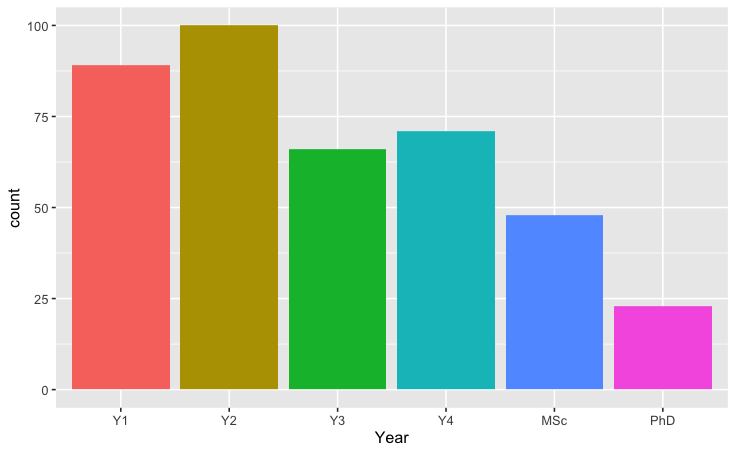

```r
data1 |>
  ggplot(aes(x = Year, fill = Year)) +
  geom_bar() +
  theme(legend.position = 'none')
```

`Attendance` – continuous

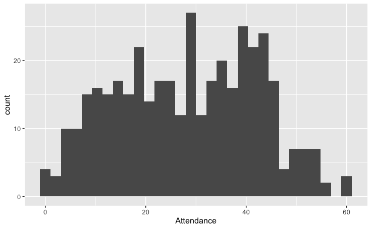

```r
data1 |>
  ggplot(aes(x = Attendance)) +
  geom_histogram()
```

## Plot the relevant variables together

Each categorical variable plotted against attendance.

`Conscientiousness`:

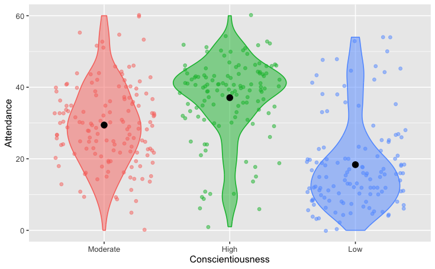

```r
data1 |>
  ggplot(aes(x = Conscientiousness, y = Attendance, fill = Conscientiousness, colour = Conscientiousness)) +
  geom_violin(alpha = 0.5) +
  geom_jitter(alpha = 0.5) +
  stat_summary(geom = 'point', fun = 'mean', colour = 'black', size = 3) +
  theme(legend.position = 'none')
```

`OnlineAccess`

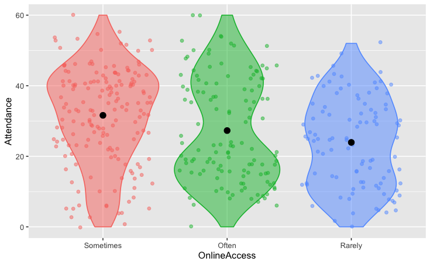

```r
data1 |>
  ggplot(aes(x = OnlineAccess, y = Attendance, fill = OnlineAccess, colour = OnlineAccess)) +
  geom_violin(alpha = 0.5) +
  geom_jitter(alpha = 0.5) +
  stat_summary(geom = 'point', fun = 'mean', colour = 'black', size = 3) +
  theme(legend.position = 'none')
```

`Year`

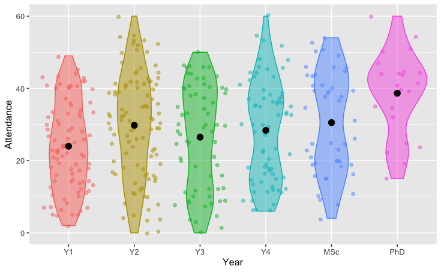

```r
data1 |>
  ggplot(aes(x = Year, y = Attendance, fill = Year, colour = Year)) +
  geom_violin(alpha = 0.5) +
  geom_jitter(alpha = 0.5) +
  stat_summary(geom = 'point', fun = 'mean', colour = 'black', size = 3) +
  theme(legend.position = 'none')
```

## Set up categorical predictors (e.g., what a priori coding scheme?)

Treatment coding. Check what contrasts we should expect.

```r
contrasts(data1$Conscientiousness)
```

```
         High Low
Moderate    0   0
High        1   0
Low         0   1
```

```r
contrasts(data1$OnlineAccess)
```

```
          Often Rarely
Sometimes     0      0
Often         1      0
Rarely        0      1
```

```r
contrasts(data1$Year)
```

```
    Y2 Y3 Y4 MSc PhD
Y1   0  0  0   0   0
Y2   1  0  0   0   0
Y3   0  1  0   0   0
Y4   0  0  1   0   0
MSc  0  0  0   1   0
PhD  0  0  0   0   1
```

## Set up continuous predictors (e.g., any transformations?)

NA

## Think what the model coefficients might look like

What coefs will we have?

- `(Intercept)` - mean `Attendance` when `Consc` = moderate, `OnlineAccess` = Sometimes, and `Year` = Y1
- `ConscientiousnessHigh` - moderate vs. high - positive
- `ConscientiousnessLow` - moderate vs. low - negative
- `OnlineAccessOften` - sometimes vs. often - negative
- `OnlineAccessRarely` - sometimes vs. rarely - even more negative
- `YearY2` - Y1 vs Y2 - pos
- `YearY3` - Y1 vs Y3 - small pos
- `YearY4` - Y1 vs Y4 - pos
- `YearMSc` - Y1 vs MSc - pos
- `YearPhD` - Y1 vs PhD - big pos

## Formally state null and alternative hypotheses

We’ll end up writing something about betas being equal or not equal to zero, but we gotta define those betas in the context of the linear model first. Otherwise beta1 could be anything!

$$\begin{align}
\text{Attendance} ~=~ & \beta_0 +
(\beta_1 \cdot \text{C}_{\text{High}}) +
(\beta_2 \cdot \text{C}_{\text{Low}}) +
(\beta_3 \cdot \text{OA}_{\text{Often}}) +
(\beta_4 \cdot \text{OA}_{\text{Rarely}}) + \\
& (\beta_5 \cdot \text{Y}_{\text{Y2}}) +
(\beta_6 \cdot \text{Y}_{\text{Y3}}) +
(\beta_7 \cdot \text{Y}_{\text{Y4}}) +
(\beta_8 \cdot \text{Y}_{\text{MSc}}) +
(\beta_9 \cdot \text{Y}_{\text{PhD}}) +
\epsilon
\end{align}$$
where C = Conscientiousness, OA = Online Access, and Y = Year.

The H0 = all the non-Intercept betas are equal to 0. That means we can reject the H0 as soon as any single one of those is sufficiently unlikely to equal 0.

$$\begin{align}
H_0 &: \text{All}\ \beta_j = 0\ \text{(for j = 1, 2, 3, 4, 5, 6, 7,
8, 9)}\\
H_1 &: \text{At least one}\ \beta_j \neq 0\ \text{(for j = 1, 2, 3,
4, 5, 6, 7, 8, 9)}
\end{align}$$

# (2) Model fitting

## Fit the linear model to the data

```r
m1 <- lm(Attendance ~ Conscientiousness + OnlineAccess + Year, data = data1)
```

# (3) After model fitting

## Check model assumptions

**Linearity:** Assumed bc categorical.

**Independence of errors:** Assumed bc between-subj design.

**Normality of errors:**

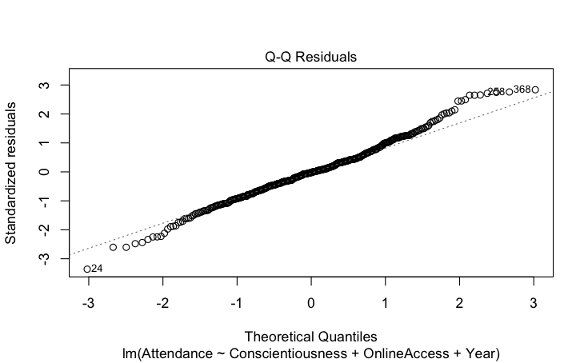

```r
plot(m1, which = 2)
```

Not a cause for concern.

**Equal variance of errors:**

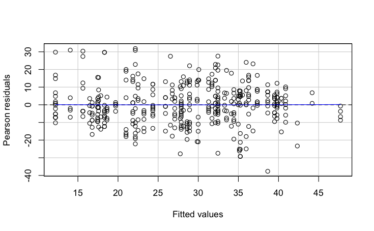

```r
car::residualPlot(m1)
```

Enough of a horizontal line + random cloud that it looks OK.

## Bootstrap the linear model

NA

## Run diagnostics for multicollinearity

```r
car::vif(m1)
```

```
                      GVIF Df GVIF^(1/(2*Df))
Conscientiousness 1.041823  2        1.010296
OnlineAccess      1.030371  2        1.007508
Year              1.044315  5        1.004346
```

All close to 1, so not a cause for worry.

## Interpret the model estimates

```r
summary(m1)
```

```
Call:
lm(formula = Attendance ~ Conscientiousness + OnlineAccess +
    Year, data = data1)

Residuals:
    Min      1Q  Median      3Q     Max
-37.657  -6.990  -0.279   6.085  31.844

Coefficients:
                      Estimate Std. Error t value Pr(>|t|)
(Intercept)             27.874      1.533  18.179  < 2e-16 ***
ConscientiousnessHigh    7.366      1.392   5.292 2.03e-07 ***
ConscientiousnessLow   -10.292      1.399  -7.359 1.12e-12 ***
OnlineAccessOften       -3.533      1.339  -2.639 0.008649 **
OnlineAccessRarely      -5.378      1.441  -3.732 0.000218 ***
YearY2                   4.574      1.657   2.760 0.006049 **
YearY3                   3.418      1.853   1.844 0.065926 .
YearY4                   4.266      1.817   2.347 0.019418 *
YearMSc                  5.649      2.046   2.760 0.006051 **
YearPhD                 12.484      2.661   4.692 3.76e-06 ***
---
Signif. codes:  0 ‘***’ 0.001 ‘**’ 0.01 ‘*’ 0.05 ‘.’ 0.1 ‘ ’ 1

Residual standard error: 11.35 on 387 degrees of freedom
Multiple R-squared:  0.3574,    Adjusted R-squared:  0.3424
F-statistic: 23.91 on 9 and 387 DF,  p-value: < 2.2e-16
```

How much variance explained? Adjusted R^2: 34%

Slopes go in predicted directions? Yes.

Reject H0? Yes, because at least one of the slope coefficients is significantly different from zero.

Interpretation for individual coefficients (**important: this is more redundant, informal, and mathematical than your write-ups should be! just let this be a guide/template for you to work out what each number means**):

`Intercept`:

- The intercept gives you the mean outcome when all the predictors are equal to 0.
- For the treatment-coded predictors, that means “when everything is at its reference level”.
- So: when C = Moderate, OA = Sometimes, and Y = Y1, the mean attendance is 27.9.
- (And this number is significantly different from zero, but that’s not a hypothesis we were interested in testing.)

`ConscientiousnessHigh`:

- When OA = Sometimes (ref level) and Y = Y1 (ref level), the difference in attendance between C = Moderate and C = High is about 7.4.
- This means that when OA = Sometimes, Y = Y1, and C = High, the mean attendance is 27.9 + 7.4 = 35.3.
- The difference between Moderate and High conscientiousness, when everything else is at its ref level, is significant at alpha = 0.05.

`ConscientiousnessLow`:

- When OA = Sometimes (ref level) and Y = Y1 (ref level), the difference in attendance between C = Moderate and C = Low is about –10.3.
- This means that when OA = Sometimes, Y = Y1, and C = Low, the mean attendance is 27.9 – 10.3 = 17.6.
- The difference between Moderate and Low conscientiousness, when everything else is at its ref level, is significant at alpha = 0.05.

`OnlineAccessOften`:

- When C = Moderate (ref level) and Y = Y1 (ref level), the difference in attendance between OA = Sometimes and OA = Often is about –3.5.
- This means that when C = Moderate, Y = Y1, and OA = Often, the mean attendance is 27.9 – 3.5 = 24.4.
- The difference between accessing materials Sometimes and Often, when everything else is at its ref level, is significant at alpha = 0.05.

`OnlineAccessRarely`:

- When C = Moderate (ref level) and Y = Y1 (ref level), the difference in attendance between OA = Sometimes and OA = Rarely is about –5.4.
- This means that when C = Moderate, Y = Y1, and OA = Rarely, the mean attendance is 27.9 – 5.4 = 22.5.
- The difference between accessing materials Sometimes and Rarely, when everything else is at its ref level, is significant at alpha = 0.05.

`YearY2`:

- When C = Moderate (ref level) and OA = Sometimes (ref level), the difference in attendance between Year = Y1 and Year = Y2 is about 4.6.
- This means that when C = Moderate, OA = Sometimes, and Y = Y2, the mean attendance is 27.9 + 4.6 = 32.5.
- The difference between Year 1 and Year 2, when everything else is at its ref level, is significant at alpha = 0.05.

`YearY3`:

- When C = Moderate (ref level) and OA = Sometimes (ref level), the difference in attendance between Year = Y1 and Year = Y3 is about 3.4.
- This means that when C = Moderate, OA = Sometimes, and Y = Y3, the mean attendance is 27.9 + 3.4 = 31.3.
- The difference between Year 1 and Year 3, when everything else is at its ref level, is NOT significant at alpha = 0.05.

`YearY4`:

- When C = Moderate (ref level) and OA = Sometimes (ref level), the difference in attendance between Year = Y1 and Year = Y4 is about 4.3.
- This means that when C = Moderate, OA = Sometimes, and Y = Y2, the mean attendance is 27.9 + 4.3 = 32.2.
- The difference between Year 1 and Year 4, when everything else is at its ref level, is significant at alpha = 0.05.

`YearMSc`:

- When C = Moderate (ref level) and OA = Sometimes (ref level), the difference in attendance between Year = Y1 and Year = MSc is about 5.6.
- This means that when C = Moderate, OA = Sometimes, and Y = Y2, the mean attendance is 27.9 + 5.6 = 33.5.
- The difference between Year 1 and MSc, when everything else is at its ref level, is significant at alpha = 0.05.

`YearPhD`:

- When C = Moderate (ref level) and OA = Sometimes (ref level), the difference in attendance between Year = Y1 and Year = PhD is about 12.5.
- This means that when C = Moderate, OA = Sometimes, and Y = Y2, the mean attendance is 27.9 + 12.5 = 40.4.
- The difference between Year 1 and PhD, when everything else is at its ref level, is significant at alpha = 0.05.

## Run sensitivity analysis

NA

## Get estimated marginal means

NA

## Plot estimated marginal means

NA

## Create and test manual contrasts

NA

## Write up your analysis

[in lab]